# MATH5741M: Statistical Theory and Methods

Benjamin Thorpe

2022-01-15

Benjamin Thorpe (b.thorpe@leeds.ac.uk)  
Saturday January 15, 2022

# Practical 9

Before this practical, please read all of Chapter 6. This practical will focus on hypothesis testing and confidence intervals in situations where we have two samples.

## Paired data

Recall the situation described last week: a famous faith healer claims that his prayers can significantly improve the lung function of viewers of his television programme. We investigated this by taking a sample of his viewers and measuring the variable $X$, their FEV1: the volume (in litres) of air they can exhale in one second.

This week we aim to get a more direct assessment of the effect of the preacher’s prayers. Each of the $9$ participants in our experiment had their FEV1 measured on two occasions: both before and after the prayer.

| Before: | 4.0 | 4.1 | 2.3 | 2.3 | 4.2 | 3.6 | 3.1 | 2.8 | 4.9 |
| --- | --- | --- | --- | --- | --- | --- | --- | --- | --- |
| After: | 4.1 | 3.9 | 2.6 | 2.2 | 3.9 | 3.6 | 3.2 | 2.8 | 4.5 |

**Exercise 1** Why should we treat our two samples as paired, not independent? Produce a plot and a numerical summary to support your answer. Estimate the mean difference and perform an appropriate t-test. Do we reject the claim that prayer does not affect lung function?

## Independent samples

Suppose that we take a random sample of $n_1 = 30$ heart surgery patients who have undergone an experimental method of surgery. We observe the LVEF (left ventricular ejection fraction) of each patient:

```r
x1 <- c(10, 28, 32, 38, 40, 42, 46, 48, 49,
        49, 51, 58, 59, 60, 60, 61, 61, 62,
        65, 66, 73, 75, 77, 77, 77, 78, 83,
        84, 95, 98)
```

Suppose that, for comparison, we independently take a random sample of $n_2 = 22$ patients who have undergone the standard method of surgery, and observe their LVEFs:

```r
x2 <- c(25, 28, 34, 37, 40, 41, 42, 42, 44,
        45, 46, 46, 47, 52, 55, 56, 60, 67,
        67, 74, 76, 78)
```

Our goal is to test, at the $5\%$ significance level, whether the mean LVEF in the population of patients who receive the experimental surgery is the same as that of the population who receive the standard surgery.

**Exercise 2** Using R’s built-in functions, calculate the quantities $\overline{x}_1 - \overline{x}_2$, $s_{1}$, $s_2$ and $t_{n_1 + n_2 - 2}(\alpha/2)$ from Theorem 6.3 in the lecture notes. Use these to calculate $s_p$ and thus to calculate a $95\%$-confidence interval. Check your confidence interval using the function `t.test()`:

```r
t.test(x = x1, y = x2, mu = 0, paired = FALSE, var.equal = TRUE, conf.level = 0.95)
```

**Exercise 3** Interpret your interval. What assumptions have you made here? Briefly check them and say which of them you might doubt.

**Exercise 4** Now calculate $\nu$ and $t_{\nu}(\alpha/2)$ from Theorem 6.4 in the lecture notes and use these to calculate a $95\%$-confidence interval. Check your answer using the `t.test()` function but with `var.equal = FALSE`. Interpret your confidence interval.

**Exercise 5** Which of these confidence intervals might lead us to a type I error? Which might lead us to a type II error? What are the possible real-life consequences of type I and type II errors in this example?

## Plotting confidence intervals

This section will allow you to practise an important skill: reverse engineering someone else’s code and adapting it for your own purposes (a skill that should be used responsibly). The figure below is an example of a forest plot, as provided in the coursework guidance.

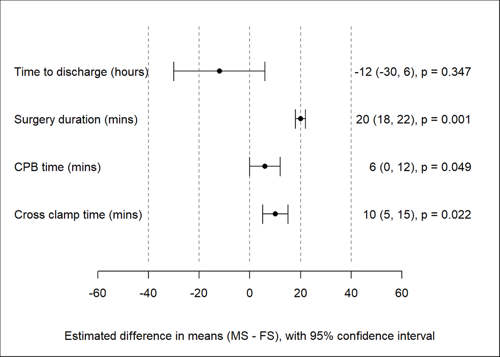

Figure 1: An example of a caterpillar/forest plot of four $95\%$-confidence intervals for four different parameters in a surgical trial.

This figure presents the results of four analyses comparing surgical outcomes for two different methods of heart surgery: mini-sternotomy (MS) and full sternotomy (FS). Although there are packages in R that can help you to create forest plots, we can achieve greater control and flexibility by creating plots using only the basic tools in R. This allows us to completely control the positioning of each feature of the plot.

The code below shows how to create this plot. Try to understand each step and see if you can modify this code for the analyses in your coursework. Running the code one box at a time will help your understanding.

```r
# Analysis labels for the left side:

analysis = c("Cross clamp time (mins)",
             "CPB time (mins)",
             "Surgery duration (mins)",
             "Time to discharge (hours)")

# Results of each test (estimated mean,
# upper CI limit, lower CI limit, p-value):

estimate  =  c(10, 6, 20, -12)
upper     =  c(15, 12, 22, 6)
lower     =  c(5, 0, 18, -30)
pval      =  c(0.022,0.049,0.001, 0.347)

# Note that the order of the results in each vector
# must match the order of the labels in the
# vector "analysis".
```

```r
# Set the margin widths:

par(mar = c(6,6,1,6))

# Create an empty plot of a suitable
# size (considering the width of your
# confidence intervals):

plot(x = 0,                                  # One point at (0,0).
     xlim = c(-60, 60), ylim=c(0, 5),        # Axis limits.
     type = "n", xaxt = "n", yaxt="n",       # No points, no axes drawn.
     xlab = NULL, ylab= NULL, ann = FALSE,   # No axis labels or numbers.
     bty="n")                                # No box.
```

```r
# Add a horizontal (side = 1) axis:

axis(side = 1, cex.axis = 1)

# Add an axis label 4 lines below the axis:

mtext("Estimated difference in means (MS - FS), with 95% confidence interval",
      side = 1, line = 4)
```

```r
# Add some grid lines, preferably lined up
# with the numbers on the horizontal axis:

for(i in c(-40, -20, 0, 20, 40)){

  lines(c(i, i), c(0, 5), lty = 2, col = "gray53")

}
```

```r
# Add labels for each analysis on the left (side = 2)
# at vertical heights of 1, 2, 3 and 4:

verticalpos = 1:4

mtext(text = analysis,  at = verticalpos,
      side = 2, line = 5, outer = FALSE, las = 1, adj = 0)

# Try changing the "line" option to move these closer to
# or away from the plotted intervals.
```

```r
# Plot the four point estimates (centres
# of the CIs for each analysis):

points(estimate, verticalpos, pch = 16)
```

```r
# Plot the four interval estimates:

for(i in 1:4 ){

  lines(c(lower[i], upper[i]), c(verticalpos[i], verticalpos[i]))

  lines(c(lower[i], lower[i]), c(verticalpos[i] + 0.2, verticalpos[i] - 0.2))

  lines(c(upper[i], upper[i]), c(verticalpos[i] + 0.2, verticalpos[i] - 0.2))

}
```

```r
# Now we add numerical results on the right (side = 4), but we
# need to put them into a nice form first. Note that
# paste() merges words and numbers, and formatC()
# allows us to control the number of decimal places.

est <- formatC(estimate, format='f', digits = 0)

P <- formatC(pval , format = 'f', digits = 3)

pval <- paste("p =", P)    # Type pval to see what this does.

L <- formatC(lower, format = 'f', digits = 0)
U <- formatC(upper, format = 'f', digits = 0)

interval <- paste("(", L, ", ", U, "),", sep = "")   # Type interval to check.

# Putting it all together:

results <- paste(est, interval, pval)

# Add to the plot:

mtext(text = results, at = verticalpos,
      side = 4, line = 4, outer = FALSE, las = 1, adj = 1)
```

```r
# Like a Christmas present, an R
# plot belongs in a box:

box("inner")
```

If anything here is not clear, use the help pages (e.g. `?mtext`). Try playing around with the values of graphical parameters such as `las` and `adj` to see what they do.

If you use this in your coursework then please remember that, for two-sample comparisons, the graph should clearly indicate the direction of the comparison. For example in the analysis labels (on the left), you might want to specify that the difference estimated is “Anger - Enjoyment” (for example), so that if the confidence interval is negative then it’s clear that age at first kill is greater for killers motivated by enjoyment than for those motivated by anger. If the direction of the comparison is not specified in the labels, then the reader won’t know if the estimate is for “Anger - Enjoyment” or “Enjoyment - Anger”.

# Solutions

## Solution to Exercise 1

The data are naturally paired because they are repeated measurements in the same sample of individuals. Measurements within the same individual are unlikely to be independent of each other. We can check using a scatter plot and a correlation:

```r
y <- c(4.0, 4.1, 2.3, 2.3, 4.2, 3.6, 3.1, 2.8, 4.9)
x <- c(4.1, 3.9, 2.6, 2.2, 3.9, 3.6, 3.2, 2.8, 4.5)
```

```r
plot(x, y)
cor(x, y)
```

[output not shown]

```r
# We could calculate differences
# and do a t-test:

d <- x - y
mean(d)
```

```
## [1] -0.05555556
```

```r
t.test(d, alternative = "two.sided", mu = 0, conf.level = 0.95)
```

```
##
##  One Sample t-test
##
## data:  d
## t = -0.76249, df = 8, p-value = 0.4676
## alternative hypothesis: true mean is not equal to 0
## 95 percent confidence interval:
##  -0.2235720  0.1124609
## sample estimates:
##   mean of x
## -0.05555556
```

```r
# OR we could just use appropriate
# options (paired = TRUE) in the
# t.test() function:

t.test(x, y, alternative = "two.sided", paired = TRUE, conf.level = 0.95)
```

```
##
##  Paired t-test
##
## data:  x and y
## t = -0.76249, df = 8, p-value = 0.4676
## alternative hypothesis: true difference in means is not equal to 0
## 95 percent confidence interval:
##  -0.2235720  0.1124609
## sample estimates:
## mean of the differences
##             -0.05555556
```

```r
# Either way, we should we check our assumptions:

pearson.test(d)
shapiro.test(d)
qqnorm(d)
```

[output not shown]

Our point estimate for the average change in FEV1 is small and negative ($\overline{d} \approx -0.05$). Our interval estimate is roughly $(-0.22, 0.11)$ which obviously can’t reject the claim that the (population) mean change in FEV1 is $0$. Even the most optimistic values for this change that we can’t reject (around $0.11$ litres) are still fairly small improvements (a quick online search suggests that even these might be considered clinically insignificant (https://www.atsjournals.org/doi/pdf/10.1164/rccm.201310-1863PP). Therefore our results suggest that prayer does not have a significant effect on lung function.

## Solution to Exercise 2

```r
x1 <- c(10, 28, 32, 38, 40, 42, 46, 48, 49, 49, 51, 58, 59, 60, 60, 61, 61, 62, 65, 66, 73, 75, 77, 77, 77, 78, 83, 84, 95, 98)

x2 <- c(25, 28, 34, 37, 40, 41, 42, 42, 44, 45, 46, 46, 47, 52, 55, 56, 60, 67, 67, 74, 76, 78)

meandiff <- mean(x1) - mean(x2)

s1 <- sd(x1)
s2 <- sd(x2)

t <- qt(p = 0.975, df = 30 + 22 - 2)

sp <- sqrt( ((30 - 1)*s1^2 + (22 - 1)*s2^2)/(30 + 22 - 2)  )

CI <- meandiff + c(-1, 1) * t * sp * sqrt(1/22 + 1/30)

CI
```

```
## [1] -0.2141772 20.1656924
```

```r
t.test(x = x1, y = x2, mu = 0, paired = FALSE, var.equal = TRUE, conf.level = 0.95)
```

```
##
##  Two Sample t-test
##
## data:  x1 and x2
## t = 1.9663, df = 50, p-value = 0.05482
## alternative hypothesis: true difference in means is not equal to 0
## 95 percent confidence interval:
##  -0.2141772 20.1656924
## sample estimates:
## mean of x mean of y
##  60.06667  50.09091
```

## Solution to Exercise 3

The confidence interval does contain $0$, so we are unable to reject the hypothesis that average LVEF is the same after the two surgeries.

```r
par(mfrow = c(2,2))
hist(x1)
hist(x2)
qqnorm(x1)
qqnorm(x2)

sd(x1)^2
sd(x2)^2
```

[output not shown]

## Solution to Exercise 4

```r
v1 <- s1^2/30
v2 <- s2^2/22

nu <- (v1 + v2)^2 / (v1^2/29 + v2^2/21)

t <- qt(p = 0.975, df = nu)

CI <- meandiff + c(-1, 1) * t * sqrt(v1 + v2)

t.test(x = x1, y = x2, mu = 0, paired = FALSE, var.equal = FALSE, conf.level = 0.95)
```

```
##
##  Welch Two Sample t-test
##
## data:  x1 and x2
## t = 2.0548, df = 49.961, p-value = 0.04515
## alternative hypothesis: true difference in means is not equal to 0
## 95 percent confidence interval:
##   0.2243523 19.7271629
## sample estimates:
## mean of x mean of y
##  60.06667  50.09091
```

The confidence interval does not contain $0$, so we can reject the hypothesis that average LVEF is the same after the two surgeries. The experimental surgery therefore appears to have an effect on LVEF. Given that our confidence interval contains only positive values, this suggests that the experimental surgery is superior to the standard surgery.

## Solution to Exercise 5

A type I error is a false rejection of a true null. Our interpretation of the second confidence interval might be a type I error. This could lead us to falsely conclude that this surgery is more effective than the standard surgery when, in fact, average LVEF is the same in both populations. This might result in patients receiving the experimental surgery, even though there are no real benefits in LVEF relative to the standard surgery.

A type II error is a failure to reject a false null hypothesis. Our interpretation of the first confidence interval might lead us to a type II error. This could lead us to falsely conclude that neither treatment is superior to the other when, in fact, one of the two populations has a higher average LVEF. This might result in patients being denied the superior surgery.